# Conformal Prediction — Sulam

Conformal Prediction

How to build predictors with uncertainty

Jeremias Sulam

2nd Spring School of Deep Learning

ICC, CONICET–UBA · November 2026

[figure not shown]

[figure not shown]

## AI: a paradigm shift

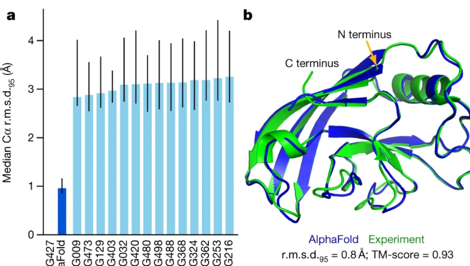

3D protein structure from sequence, with accuracy close to experimental in CASP14.

Jumper et al., Nature 2021

[video not shown]

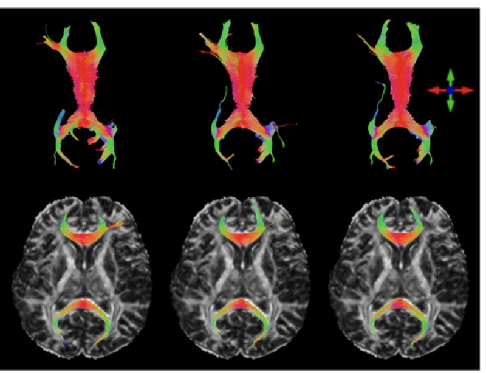

Magnetic susceptibility tensors of the brain (MRI) reconstructed from fewer acquisition orientations.

DeepSTI: Fang et al., MedIA 2023

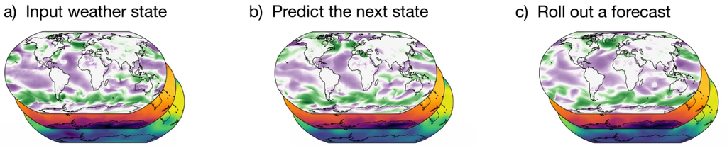

10-day weather forecasts, better than the ECMWF operational system on 90% of 1380 evaluated targets.

Lam et al., Science 2023

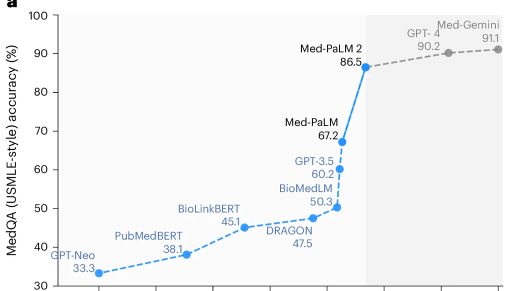

Language models answering 86.5% of medical exam questions correctly (MedQA).

Singhal et al., Nature Medicine 2025

## … but sometimes it fails

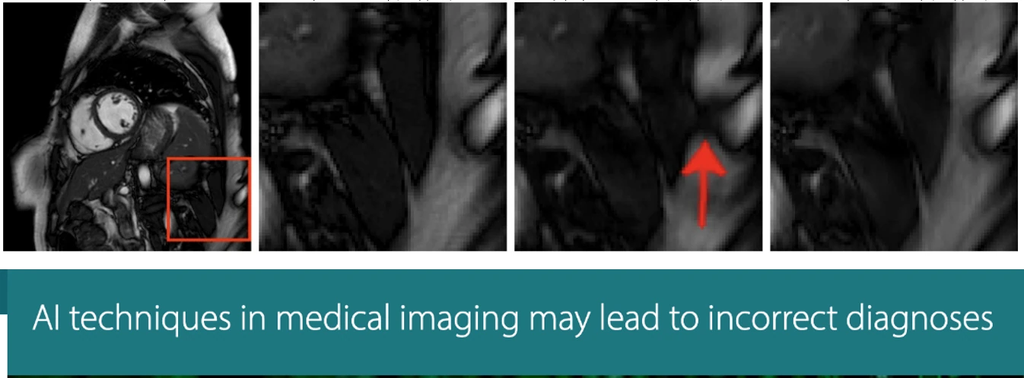

Small perturbations in the measurements produce false structures (arrow) in deep-network reconstructions.

Univ. of Cambridge, May 12, 2020 · Antun et al., PNAS 2020

[figure not shown]

Commercial sepsis model: AUC 0.63 on external validation; it missed 67% of cases.

MedCity News, June 23, 2021 · Wong et al., JAMA Intern. Med. 2021

[figure not shown]

COVID-19 classifiers on chest X-rays use spurious signals and fail at new hospitals.

GeekWire, June 3, 2021 · DeGrave, Janizek & Lee, Nat. Mach. Intell. 2021

[figure not shown]

A legal brief cited six nonexistent court decisions generated by an LLM.

The New York Times, May 27, 2023 · Mata v. Avianca, S.D.N.Y. 2023

Predictors usually give us only a predicted value.

How can we attach a rigorous measure of uncertainty to these predictions?

## Point prediction

Training data $(X_i, Y_i)\sim P$, $\ i=1,\dots,n$, and a loss $\ell$:
$$\fh = \argmin_{f\in\mathcal F}\ \frac1n\sum_{i=1}^n \ell\big(f(X_i),Y_i\big) \quad\approx\quad f^\star=\argmin_f\ \E\big[\ell(f(X),Y)\big]$$

Regression: $\ Y\in\R$

$$f^\star(x)=\E[Y\mid X=x]$$
squared loss $\ \ell=(f(x)-y)^2$

Classification: $\ Y\in[K]$

$$f^\star_k(x)=\P(Y=k\mid X=x)$$
cross-entropy; $\ \hat y(x)=\argmax_k \fh_k(x)$

## Point prediction

$X$ = age and sex. $\ Y$ = weight (kg).

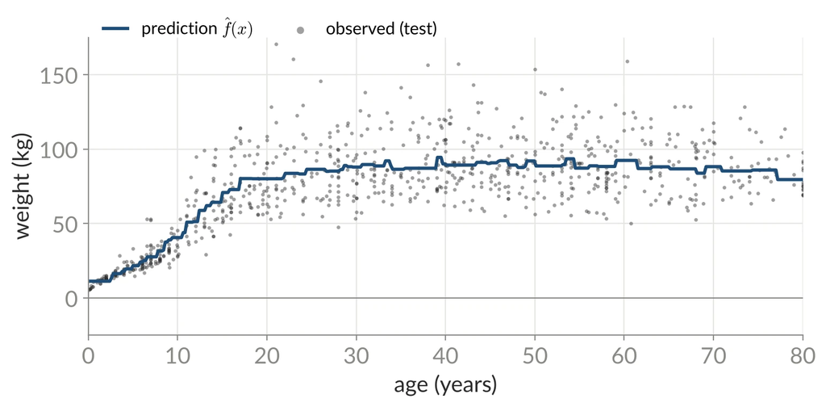

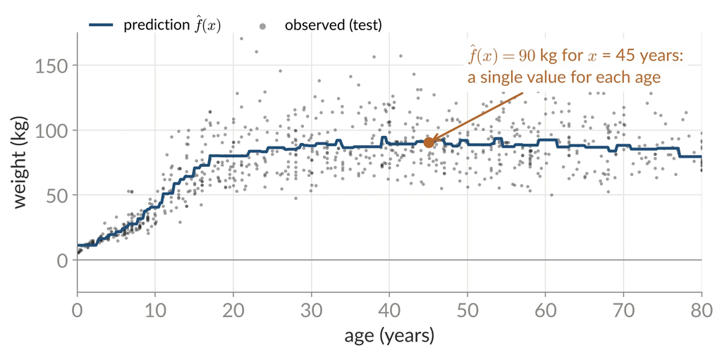

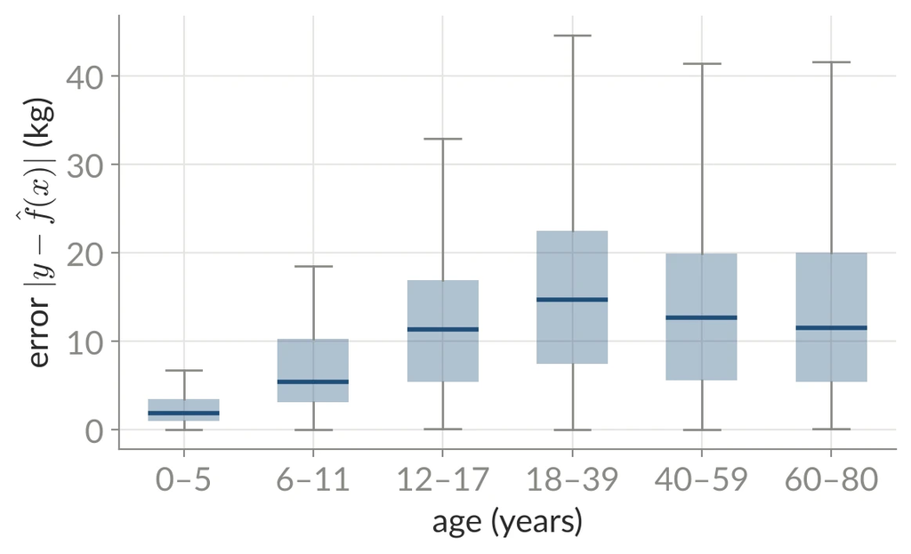

Test error $|y-\fh(x)|$: on average 2.6 kg for ages 0–5 and 17 kg for ages 18–39.

The error depends on $x$. What is the uncertainty of each prediction?

[NHANES 2009–2012, n = 6,724; Pruim, 2015]

Q1: How do we build precise uncertainty intervals?

Q2: How does it generalize, and where is it used?

## Prediction intervals

Around any predictor:
$$C_\lambda(x) = \big[\fh(x)-\lambda,\ \fh(x)+\lambda\big]$$

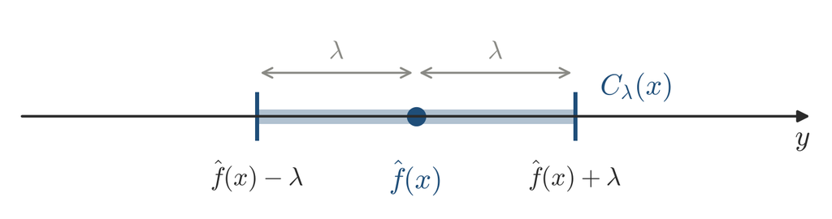

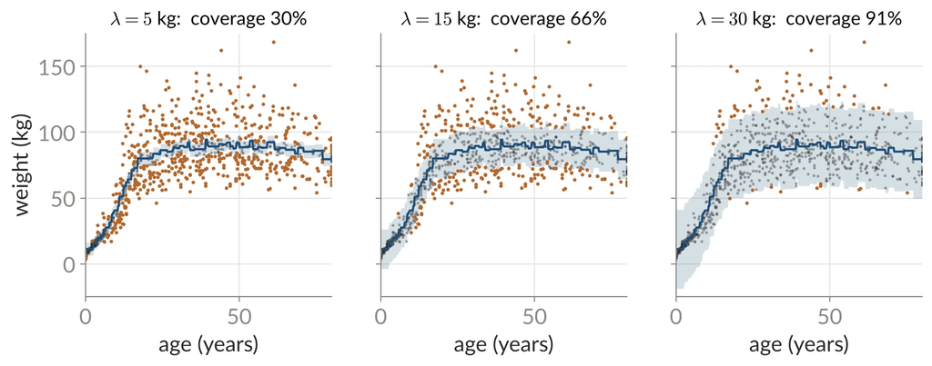

How do we choose $\lambda$ so that $\quad \P\big[Y\in C_\lambda(X)\big]\ \ge\ 1-\alpha\$?

## Prediction intervals

How do we choose $\lambda$ so that $\quad \P\big[Y\in C_\lambda(X)\big]\ \ge\ 1-\alpha\$?

- **Standard deviation of the error:** $\ \lambda = z_{1-\alpha/2}\,\hat\sigma$  
  assumes Gaussian errors, with the same variance for every $x$

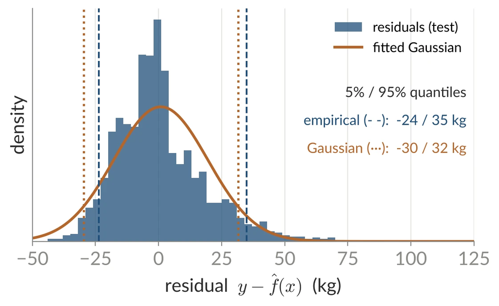

Weight vs. age: test residuals are skewed and heavy-tailed (skewness 1.3, excess kurtosis 3.5).

- **Bayesian:** credible interval of the posterior predictive distribution  
  $\ p(y\mid x,\mathcal D)=\int p(y\mid x,\theta)\,p(\theta\mid\mathcal D)\,d\theta$  
  valid if the prior and the likelihood are correct; the integral over $\theta$ is intractable for deep networks
- **MC dropout / ensembles:** mean $\pm$ deviation across passes or networks  
  approximations to the posterior with no control of the approximation error

None guarantees finite-sample $1-\alpha$ coverage without assumptions.

[Gal & Ghahramani, 2016][Lakshminarayanan et al, 2017]

## Prediction intervals

How do we choose $\lambda$ so that $\quad \P\big[Y\in C_\lambda(X)\big]\ \ge\ 1-\alpha\$?

- for **any** model $\fh$ (network, ensemble, LLM, an API)
- for **any** data distribution (no parametric assumptions)
- in **finite samples** (not asymptotic)

Requirement: $n$ labeled, “exchangeable” calibration data points.

## Split conformal

Input: an already trained predictor $\fh$ (trained on other data, or accessible only through an API) and $n$ calibration data points $(X_i,Y_i)$.

**1.** Compute the **scores** $\ s_i = |Y_i-\fh(X_i)|$, $\ i=1,\dots,n$.

**2.** $\qh$ = empirical quantile of level $\ \dfrac{\lceil (n+1)(1-\alpha)\rceil}{n}\$ of $\ s_1,\dots,s_n$.

**3.** For a new $x$: $\qquad \Ch(x)=C_{\qh}(x)=\big[\fh(x)-\qh,\ \fh(x)+\qh\big]$

[Papadopoulos, Proedrou, Vovk & Gammerman, 2002]

## Split conformal

How do we choose $\lambda$ so that $\quad \P\big[Y\in C_\lambda(X)\big]\ \ge\ 1-\alpha\$?

1. Calibration scores

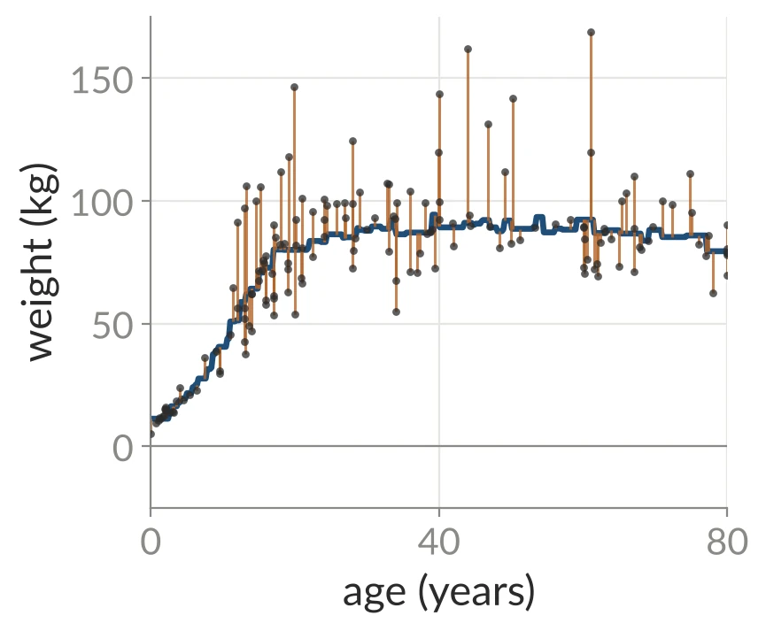

$s_i=|Y_i-\fh(X_i)|,\ \ n=1681$

→

2. Quantile of the scores

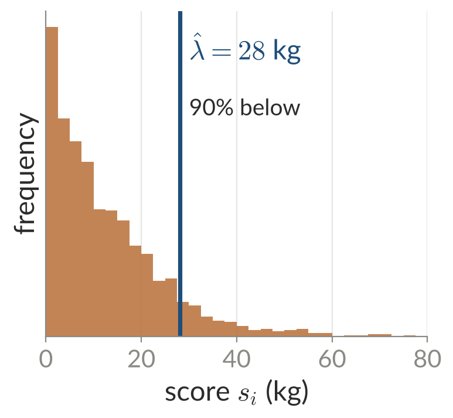

$\qh=28.0$ kg

→

3. Test intervals

$\Ch(x)=\big[\fh(x)-\qh,\ \fh(x)+\qh\big]$

## Split conformal

Theorem [Vovk et al, 2005; Lei et al, 2018]

If $(X_1,Y_1),\dots,(X_{n+1},Y_{n+1})$ are **exchangeable**, then
$$\P\big(Y_{n+1}\in\Ch(X_{n+1})\big)\ \ge\ 1-\alpha$$

The probability is over the calibration data and the test point $(X_{n+1},Y_{n+1})$.

**Exchangeable:** with $Z_i=(X_i,Y_i)$, for every permutation $\pi$,
$$(Z_1,\dots,Z_{n+1})\ \overset{d}{=}\ (Z_{\pi(1)},\dots,Z_{\pi(n+1)}).$$
For example, i.i.d. data.

## Split conformal (proof sketch)

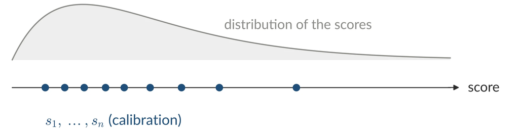

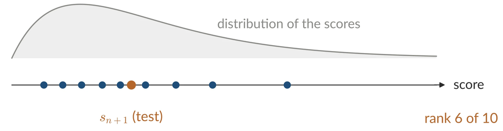

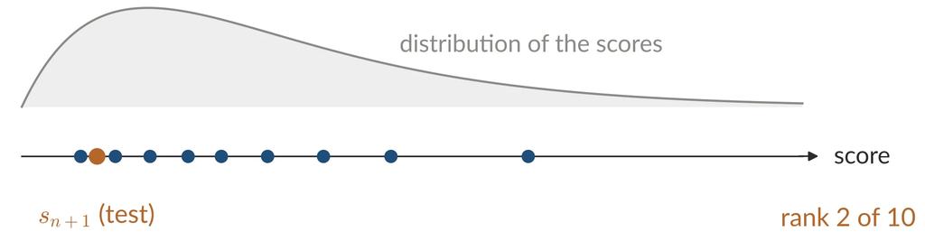

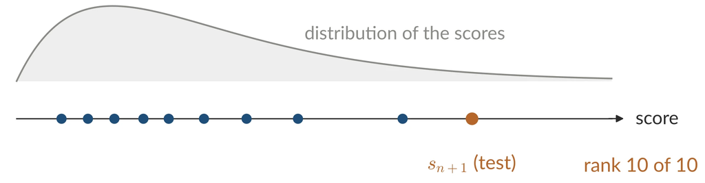

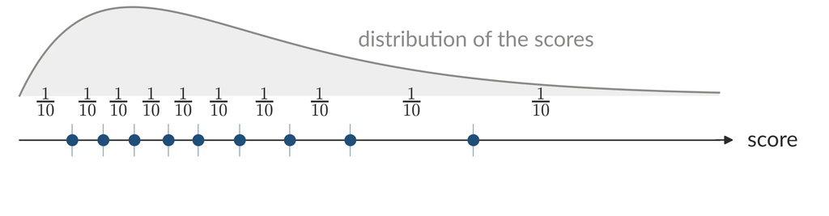

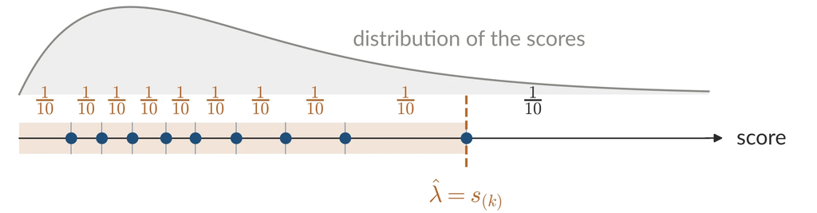

Let $s_{n+1}=|Y_{n+1}-\fh(X_{n+1})|$ be the test score.

By exchangeability, the **rank** of $s_{n+1}$ among $s_1,\dots,s_{n+1}$ is uniform on $\{1,\dots,n+1\}$.

With $k=\lceil (n+1)(1-\alpha)\rceil$ and $\qh=s_{(k)}$ (the $k$-th smallest):
$$\P\big(Y_{n+1}\in\Ch\big) = \P\big(s_{n+1}\le \qh\big) = \P\big(\text{rank}(s_{n+1}) \le k\big) = \tfrac{k}{n+1} \ge 1-\alpha \quad \square$$

The proof uses neither $\fh$ nor the law of $(X,Y)$: *distribution free*.

## Split conformal

Coverage on the 1681 test people: **89.4%**

$$\P\big(Y_{n+1}\in\Ch(X_{n+1})\big)\ \ge\ 1-\alpha$$

$\{Y_{n+1}\in\Ch(X_{n+1})\}$ is a **random event**.

With the calibration fixed:
$$\P\big(Y_{n+1}\in\Ch(X_{n+1})\mid\mathcal D_{\rm cal}\big)\ \sim\ \mathrm{Beta}(n+1-l,\ l)$$
with $l=\lfloor(n+1)\alpha\rfloor$ (scores without ties)

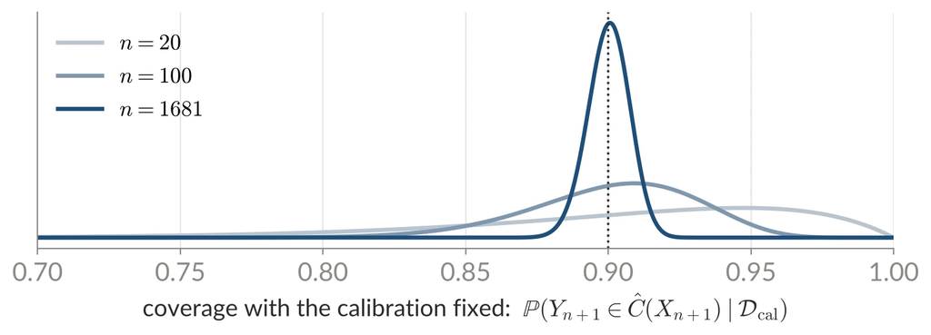

Summary (so far):

- Split conformal: $\qh$ = quantile of the errors on calibration data.
- Guarantee: **exchangeability** + a **rank** argument.
- Any model: the model determines the **width**, not the validity.
- No distributional assumptions and easy to implement: growing use in ML and AI.

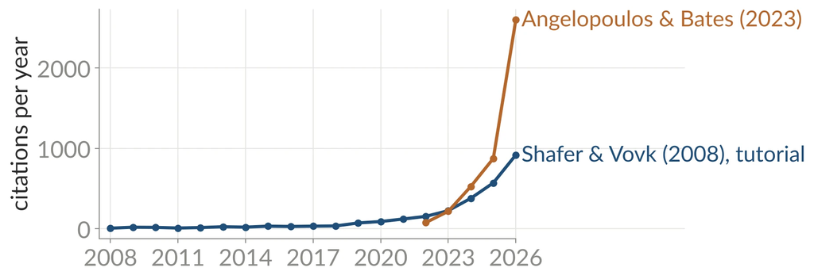

Citations per year on Google Scholar (2026: through Nov.).

**US elections (2020–2024).** On election night, The Washington Post publishes conformal intervals for the votes not yet counted.  
Cherian, Bronner & Candès, 2024

**COVID-19 deaths (CDC forecast).** The official forecast (without conformal) publishes 80% intervals 4 weeks ahead; during the 2020–21 winter wave they covered 2 of 10 weeks. Corrected with online conformal: 7 of 10.  
Angelopoulos, Candès & Tibshirani, 2023

Q1: How do we build precise uncertainty intervals?

Q2: How does it generalize, and where is it used?

CQR

classification

conditional coverage

risk control

online

Q2: How does it generalize, and where is it used?

CQR

classification

conditional coverage

risk control

online

## Marginal coverage

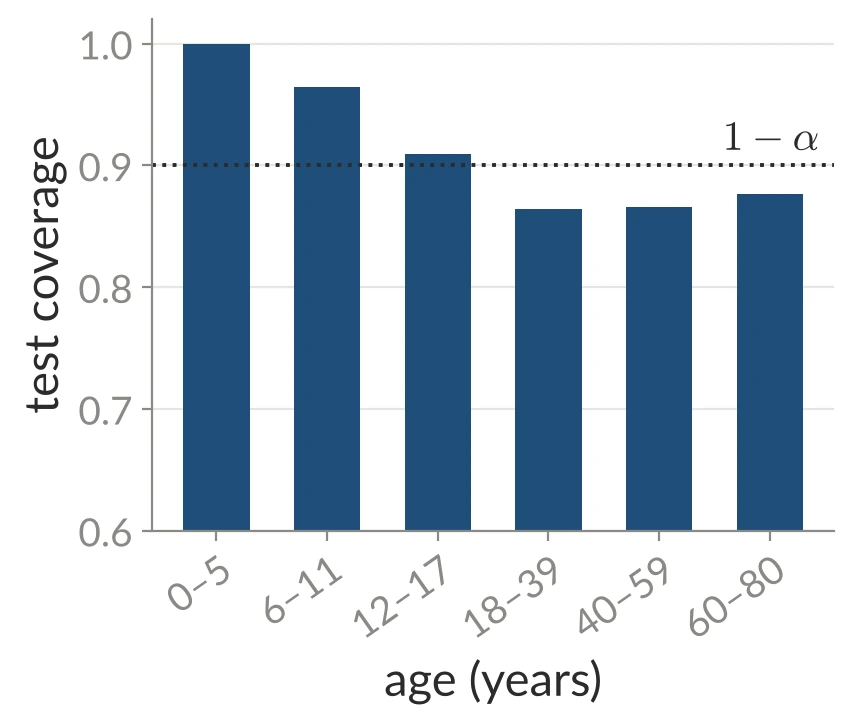

$$\P\big(Y\in\Ch(X)\big)\ge 1-\alpha \qquad\not\Rightarrow\qquad \P\big(Y\in\Ch(X)\mid X=x\big)\ge 1-\alpha$$

## Other scores

Conformal is very flexible: any heuristic measure of uncertainty can be used as a score. For example:

- Estimated standard deviation $\hat\sigma(x)$ (ensemble, MC dropout):
  $$s(x,y)=\frac{|y-\fh(x)|}{\hat\sigma(x)} \qquad\Rightarrow\qquad \Ch(x)=\fh(x)\pm\qh\,\hat\sigma(x)$$
- Quantile regression.

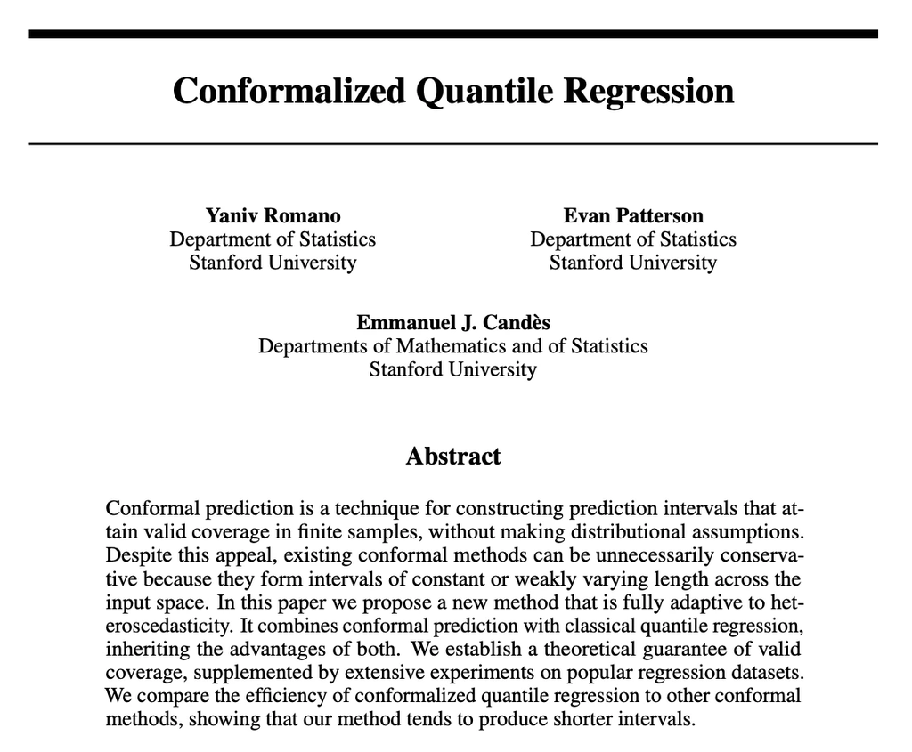

## Quantile regression (CQR)

Estimate the 5% and 95% quantiles of $Y$ given $X$: regression with the pinball loss $\ell_\tau$,

$$\hat q_\tau=\arg\min_{q}\ \sum_{i}\ell_\tau\big(Y_i,\,q(X_i)\big)$$

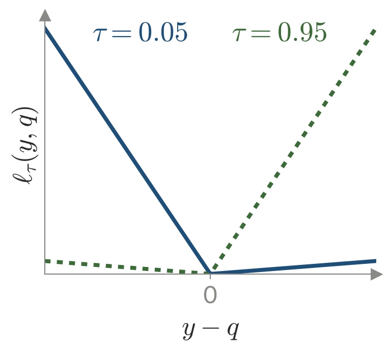

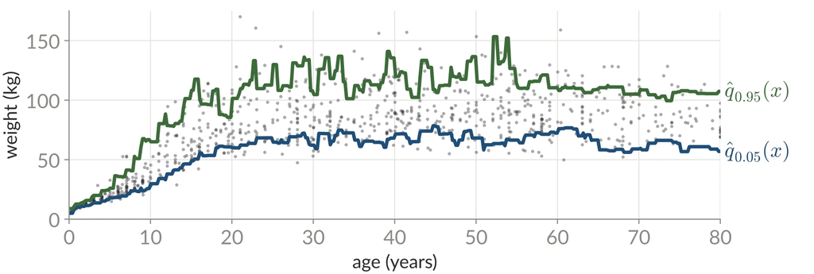

[Romano, Patterson & Candès, 2019]